# Terns within-season (summer) adult mass trajectory

Issue #10 - follow-up to issue #8

2026-09-23

# 1 Background

#5 task 4 asked whether adult mass changes over the course of the summer (early vs. late season), but used the old spring-confirmed-breeder population, which has no *weighed* within-season record after 2023 for either species - so it couldn’t say anything about recent years.

#8 established a better-covered population: adults caught **directly in the colony during summer** (new ringings + recaptures, no breeder/non- breeder split, since summer colony presence is itself the breeding evidence) - data through 2026 for Common Tern. This script re-asks the within-season question on that population, for **two window definitions** run separately: **Jun-Jul** (matches #8) and **Jun-Aug** (matches the chick window from #9, wider). For each window: is there a within-season mass pattern **in general** (pooled across years), and does that pattern **hold within each year on its own** (day-of-season x year interaction), or does it vary?

# 2 Data loading

```r
raw_dir <- "../data_raw"
if (!dir.exists(raw_dir)) raw_dir <- "data_raw"
stopifnot(dir.exists(raw_dir))

proc_dir <- "../data_processed"
if (!dir.exists(proc_dir)) proc_dir <- "data_processed"

out_dir <- "../output"
if (!dir.exists(out_dir)) out_dir <- "output"

ringing_path <- file.path(raw_dir, "ringing_data_raw.xlsx")
stopifnot(file.exists(ringing_path))

col_names_47 <- c(
  "CR1","RingReplace","Rec","RingPrefix","RingNum","Species","Sex","Age","Wing","Weight",
  "Date","Time","Place","Lat","Lon","Ringer","Country","Remarks","Net","CR2","Subsp","Tail","Head",
  "Breeding","CP1","CP2","CP3","CP4","Colour","D","M","OrigDate","OrigCountry","OrigLat","OrigLon","OrigAge",
  "OldCR1","OldCR2","OldCR3","OldMetal1","OldMetal2","OilHead","OilWings","OilUpperP","OilUnderP","OilLegs","OilSum"
)
raw <- read_excel(ringing_path, sheet = "Data", skip = 2, col_names = col_names_47)

terns <- raw %>%
  filter(Species %in% c("STEALB", "STEHIR")) %>%
  mutate(
    year = year(Date),
    month = month(Date),
    date = as.Date(Date),
    is_new = is.na(Rec) | trimws(Rec) == "",
    is_recap = trimws(Rec) == "R" & !is.na(Rec),
    is_capture = is_new | is_recap,  # excludes foreign-scheme codes (distant reports, not in-hand)
    species_label = ifelse(Species == "STEHIR", "Common Tern", "Little Tern")
  )

juvenile_ages <- c(1, 3)

build_window <- function(months) {
  terns %>%
    filter(is_capture, !(Age %in% juvenile_ages), !is.na(Weight), month %in% months) %>%
    # Date comes in as POSIXct from readxl, so a naive Date - Date
    # subtraction returns a difftime in SECONDS, not days (bug caught in
    # #5 task 4) - force both sides to Date class first.
    mutate(day_of_season = as.numeric(date - as.Date(ymd(paste0(year, "-06-01")))))
}
```

# 3 Analysis function

Reused identically for both window definitions below - pooled `Weight ~ day_of_season` regression per species, plus a `Weight ~ day_of_season * year` interaction test per species (does the within-season slope vary from year to year), plus a per-year visual (color-graded by year, following the convention from #5 task 4).

```r
format_pval <- function(p) {
  ifelse(p < 0.001, formatC(p, format = "e", digits = 2), formatC(p, format = "f", digits = 3))
}

run_within_season <- function(df, window_label) {
  pooled_stats <- df %>%
    group_by(species_label) %>%
    group_modify(~ {
      m <- lm(Weight ~ day_of_season, data = .x)
      s <- summary(m)
      tibble(
        n = nrow(.x),
        n_years = n_distinct(.x$year),
        slope_g_per_day = round(coef(m)["day_of_season"], 4),
        se = round(s$coefficients["day_of_season", "Std. Error"], 4),
        p_value = signif(s$coefficients["day_of_season", "Pr(>|t|)"], 3),
        r_squared = round(s$r.squared, 4)
      )
    }) %>%
    ungroup() %>%
    mutate(window = window_label)

  interaction_stats <- df %>%
    group_by(species_label) %>%
    filter(n_distinct(year) >= 3) %>%
    group_modify(~ {
      m <- lm(Weight ~ day_of_season * factor(year), data = .x)
      a <- anova(m)
      tibble(
        n = nrow(.x),
        n_years = n_distinct(.x$year),
        interaction_p = signif(a["day_of_season:factor(year)", "Pr(>F)"], 3)
      )
    }) %>%
    ungroup() %>%
    mutate(window = window_label)

  list(pooled = pooled_stats, interaction = interaction_stats, data = df %>% mutate(window = window_label))
}

# Year is a discrete quantity (16-17 distinct years), not a continuous one -
# scale_color_viridis_d (not _c) gives each year its own color from the
# viridis palette instead of implying a smooth gradient. The most recent
# year is additionally drawn as a thick black line on top, since it's the
# one most likely to get lost among 16 other overlapping lines/points but
# is usually the one of most immediate interest.
make_season_plot <- function(df, window_label, x_breaks, x_labels, show_points = TRUE) {
  df <- df %>% mutate(year_f = factor(year))
  latest_year <- max(df$year)
  df_latest <- df %>% filter(year == latest_year)
  # Excluded from the per-year colored-line layer below so the latest year
  # isn't drawn twice (once thin/colored, once thick/black) - the two lines
  # are numerically identical (same data, same lm fit) but overlapping them
  # made it look like two different trends at the line ends.
  df_hist <- df %>% filter(year != latest_year)

  p <- ggplot(df, aes(day_of_season, Weight, color = year_f))

  if (show_points) {
    p <- p + geom_jitter(width = 0.5, alpha = 0.35, size = 1)
  }

  p +
    geom_smooth(data = df_hist, aes(group = year_f), method = "lm", se = FALSE, linewidth = 0.5, alpha = 0.7) +
    geom_smooth(color = "grey30", method = "lm", se = FALSE, linewidth = 1, linetype = "dashed") +
    geom_smooth(data = df_latest, aes(x = day_of_season, y = Weight), inherit.aes = FALSE,
                method = "lm", se = FALSE, color = "black", linewidth = 1.6) +
    scale_color_viridis_d(name = "Year") +
    scale_x_continuous(breaks = x_breaks, labels = x_labels) +
    facet_wrap(~species_label, scales = "free_y") +
    labs(title = paste0("Adult mass within season (", window_label, ")",
                         if (show_points) "" else " - trend lines only"),
         subtitle = paste0(if (show_points) "Thin lines = per-year trend, " else "Per-year trend lines only (no raw points), ",
                            "grey dashed = pooled trend, thick black = most recent year (", latest_year, ")"),
         x = "Date within season", y = "Weight (g)") +
    theme_minimal()
}
```

# 4 Window 1: Jun-Jul (no August)

```r
w_junjul <- build_window(6:7)
kable(w_junjul %>% count(species_label, name = "n"), caption = "Jun-Jul adult weighed records by species")
```

Jun-Jul adult weighed records by species

| species_label | n |
| --- | --- |
| Common Tern | 1300 |
| Little Tern | 691 |

```r
res_junjul <- run_within_season(w_junjul, "Jun-Jul")

kable(res_junjul$pooled %>% select(-window), digits = 4,
      caption = "Pooled Weight ~ day_of_season, Jun-Jul (all years combined)")
```

Pooled Weight ~ day_of_season, Jun-Jul (all years combined)

| species_label | n | n_years | slope_g_per_day | se | p_value | r_squared |
| --- | --- | --- | --- | --- | --- | --- |
| Common Tern | 1300 | 16 | 0.0741 | 0.0202 | 0.0003 | 0.0102 |
| Little Tern | 691 | 17 | -0.0214 | 0.0128 | 0.0937 | 0.0041 |

```r
kable(res_junjul$interaction %>% select(-window),
      caption = "day_of_season x year interaction test, Jun-Jul (does the within-season slope vary by year?)")
```

day_of_season x year interaction test, Jun-Jul (does the within-season slope vary by year?)

| species_label | n | n_years | interaction_p |
| --- | --- | --- | --- |
| Common Tern | 1300 | 16 | 0.115 |
| Little Tern | 691 | 17 | 0.449 |

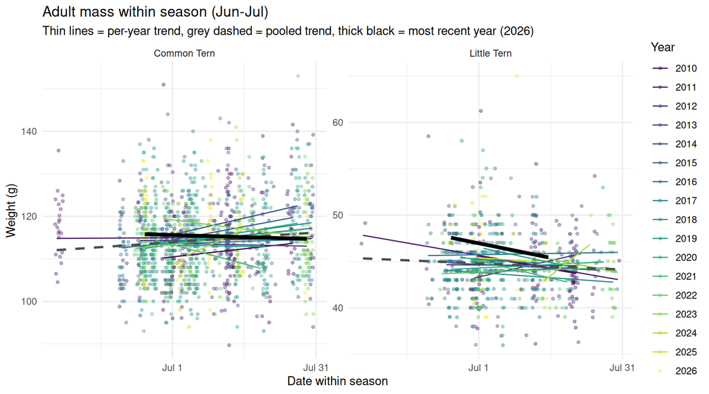

```r
make_season_plot(w_junjul, "Jun-Jul", c(0, 30, 61), c("Jun 1", "Jul 1", "Jul 31"))
```

Same data, trend lines only (no raw points) - makes the most recent year’s line (thick black) easier to pick out against the rest:

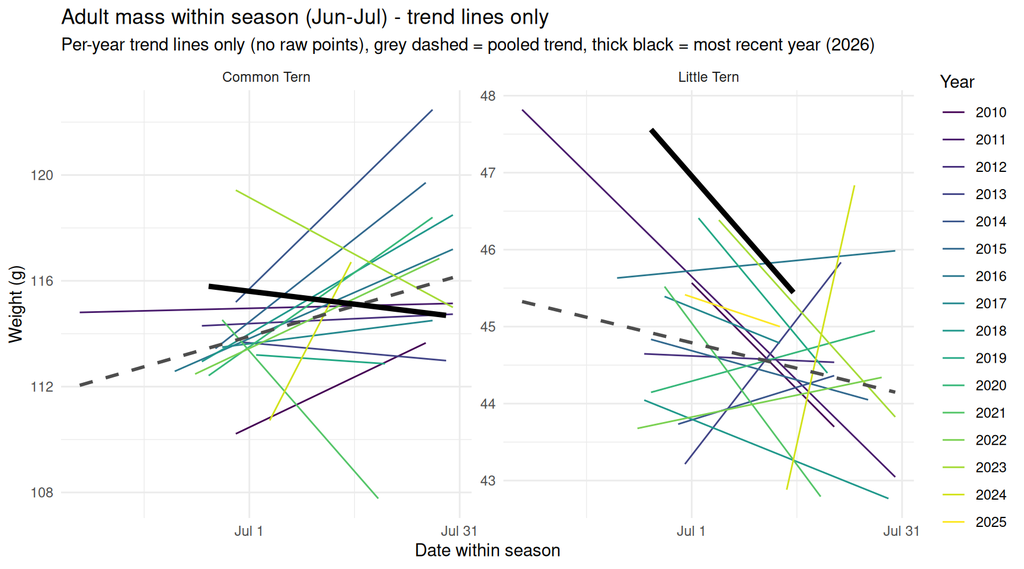

```r
make_season_plot(w_junjul, "Jun-Jul", c(0, 30, 61), c("Jun 1", "Jul 1", "Jul 31"), show_points = FALSE)
```

# 5 Window 2: Jun-Aug (including August)

```r
w_junaug <- build_window(6:8)
kable(w_junaug %>% count(species_label, name = "n"), caption = "Jun-Aug adult weighed records by species")
```

Jun-Aug adult weighed records by species

| species_label | n |
| --- | --- |
| Common Tern | 1744 |
| Little Tern | 790 |

```r
res_junaug <- run_within_season(w_junaug, "Jun-Aug")

kable(res_junaug$pooled %>% select(-window), digits = 4,
      caption = "Pooled Weight ~ day_of_season, Jun-Aug (all years combined)")
```

Pooled Weight ~ day_of_season, Jun-Aug (all years combined)

| species_label | n | n_years | slope_g_per_day | se | p_value | r_squared |
| --- | --- | --- | --- | --- | --- | --- |
| Common Tern | 1744 | 17 | 0.1389 | 0.0119 | 0.0000 | 0.0730 |
| Little Tern | 790 | 17 | -0.0144 | 0.0079 | 0.0678 | 0.0042 |

```r
kable(res_junaug$interaction %>% select(-window),
      caption = "day_of_season x year interaction test, Jun-Aug (does the within-season slope vary by year?)")
```

day_of_season x year interaction test, Jun-Aug (does the within-season slope vary by year?)

| species_label | n | n_years | interaction_p |
| --- | --- | --- | --- |
| Common Tern | 1744 | 17 | 0.0121 |
| Little Tern | 790 | 17 | 0.0522 |

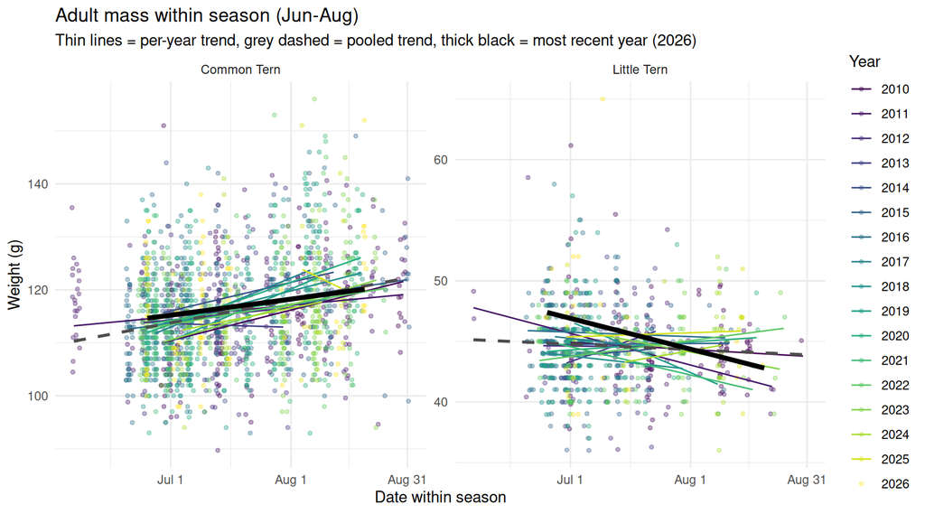

```r
make_season_plot(w_junaug, "Jun-Aug", c(0, 30, 61, 91), c("Jun 1", "Jul 1", "Aug 1", "Aug 31"))
```

Same data, trend lines only (no raw points):

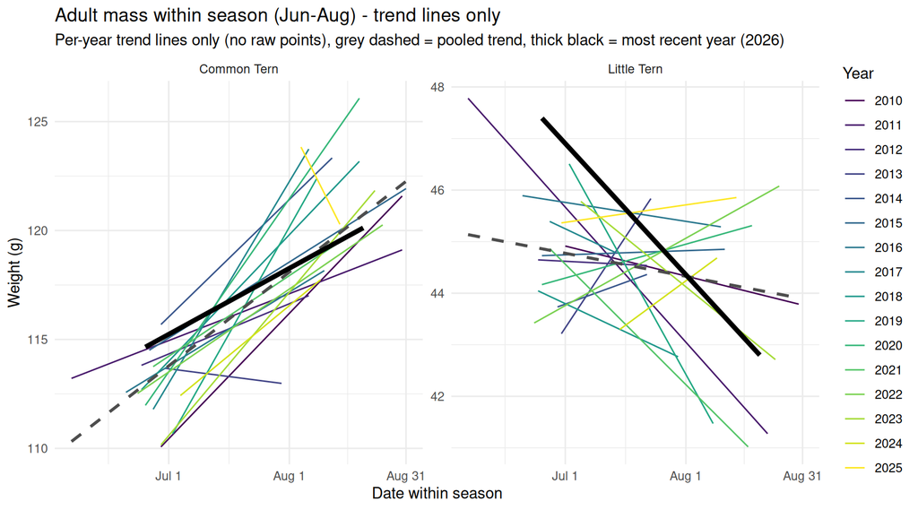

```r
make_season_plot(w_junaug, "Jun-Aug", c(0, 30, 61, 91), c("Jun 1", "Jul 1", "Aug 1", "Aug 31"), show_points = FALSE)
```

# 6 Wing-normalized mass (ratio + SMI)

Everything above uses raw `Weight`. Same wing-normalization approach as issues #6/#8/#9 - **simple ratio** (`Weight/Wing`) and **SMI** (scaled mass index, Peig & Green 2009: log-log SMA regression, each individual’s mass rescaled to what it would weigh at its species’ mean wing length). Fit **per species** (adults only here, no breeder/non-breeder split, same population as the rest of this script). Wing normalization is on firmer ground for adults than it was for chicks in #9 - wing chord is a fixed structural trait in adults, whereas in growing chicks it’s still an age/developmental-stage proxy (see NOTES.md’s discussion under #9).

```r
compute_smi <- function(df) {
  lx <- log(df$Wing)
  ly <- log(df$Weight)
  b <- sd(ly) / sd(lx)  # SMA slope
  wing_mean <- mean(df$Wing)
  df$smi <- df$Weight * (wing_mean / df$Wing) ^ b
  df$smi_b <- b
  df
}

normalize_window <- function(df) {
  df %>%
    filter(!is.na(Wing)) %>%
    mutate(mass_ratio = Weight / Wing) %>%
    group_by(species_label) %>%
    group_modify(~ compute_smi(.x)) %>%
    ungroup()
}

w_junjul_norm <- normalize_window(w_junjul)
w_junaug_norm <- normalize_window(w_junaug)

cat("Jun-Jul: Weight-only n =", nrow(w_junjul), "-> also with Wing n =", nrow(w_junjul_norm),
    sprintf("(%.1f%% retained)\n", 100 * nrow(w_junjul_norm) / nrow(w_junjul)))
```

```
## Jun-Jul: Weight-only n = 1991 -> also with Wing n = 1966 (98.7% retained)
```

```r
cat("Jun-Aug: Weight-only n =", nrow(w_junaug), "-> also with Wing n =", nrow(w_junaug_norm),
    sprintf("(%.1f%% retained)\n", 100 * nrow(w_junaug_norm) / nrow(w_junaug)))
```

```
## Jun-Aug: Weight-only n = 2534 -> also with Wing n = 2496 (98.5% retained)
```

```r
relabel_metric <- function(x) {
  x <- recode(x, Weight = "Raw mass (g)", mass_ratio = "Mass/Wing ratio", smi = "SMI (g, rescaled)")
  factor(x, levels = c("Raw mass (g)", "Mass/Wing ratio", "SMI (g, rescaled)"))
}

kable(bind_rows(w_junjul_norm %>% distinct(species_label, smi_b) %>% mutate(window = "Jun-Jul"),
                 w_junaug_norm %>% distinct(species_label, smi_b) %>% mutate(window = "Jun-Aug")),
      digits = 3, caption = "SMA slope (b) used for SMI, by species and window")
```

SMA slope (b) used for SMI, by species and window

| species_label | smi_b | window |
| --- | --- | --- |
| Common Tern | 3.048 | Jun-Jul |
| Little Tern | 2.876 | Jun-Jul |
| Common Tern | 3.191 | Jun-Aug |
| Little Tern | 2.876 | Jun-Aug |

Note: since normalization drops the small fraction of records missing `Wing` (~1-1.5%), the raw-mass numbers recomputed alongside ratio/SMI below differ very slightly from the Weight-only tables above (e.g. Common Tern Jun-Jul n=1283 here vs. n=1300 above) - this is so all three metrics below are compared on the exact same set of records, not an inconsistency.

## 6.1 Pooled trend and interaction test, all three metrics

```r
run_within_season_metric <- function(df, window_label, metric) {
  form_pooled <- as.formula(paste0(metric, " ~ day_of_season"))
  form_inter  <- as.formula(paste0(metric, " ~ day_of_season * factor(year)"))

  pooled_stats <- df %>%
    group_by(species_label) %>%
    group_modify(~ {
      m <- lm(form_pooled, data = .x)
      s <- summary(m)
      tibble(
        n = nrow(.x),
        n_years = n_distinct(.x$year),
        slope = round(coef(m)["day_of_season"], 4),
        se = round(s$coefficients["day_of_season", "Std. Error"], 4),
        p_value = signif(s$coefficients["day_of_season", "Pr(>|t|)"], 3),
        r_squared = round(s$r.squared, 4)
      )
    }) %>%
    ungroup() %>%
    mutate(window = window_label, metric = metric)

  interaction_stats <- df %>%
    group_by(species_label) %>%
    filter(n_distinct(year) >= 3) %>%
    group_modify(~ {
      m <- lm(form_inter, data = .x)
      a <- anova(m)
      tibble(
        n = nrow(.x),
        n_years = n_distinct(.x$year),
        interaction_p = signif(a["day_of_season:factor(year)", "Pr(>F)"], 3)
      )
    }) %>%
    ungroup() %>%
    mutate(window = window_label, metric = metric)

  list(pooled = pooled_stats, interaction = interaction_stats)
}

run_all_metrics <- function(df, window_label) {
  res <- list(
    Weight = run_within_season_metric(df, window_label, "Weight"),
    mass_ratio = run_within_season_metric(df, window_label, "mass_ratio"),
    smi = run_within_season_metric(df, window_label, "smi")
  )
  list(
    pooled = bind_rows(res$Weight$pooled, res$mass_ratio$pooled, res$smi$pooled) %>%
      mutate(metric = relabel_metric(metric)) %>% arrange(species_label, metric),
    interaction = bind_rows(res$Weight$interaction, res$mass_ratio$interaction, res$smi$interaction) %>%
      mutate(metric = relabel_metric(metric)) %>% arrange(species_label, metric)
  )
}

norm_junjul <- run_all_metrics(w_junjul_norm, "Jun-Jul")
norm_junaug <- run_all_metrics(w_junaug_norm, "Jun-Aug")
```

```r
kable(norm_junjul$pooled %>% select(-window), digits = 4,
      caption = "Pooled value ~ day_of_season, Jun-Jul, all three metrics")
```

Pooled value ~ day_of_season, Jun-Jul, all three metrics

| species_label | n | n_years | slope | se | p_value | r_squared | metric |
| --- | --- | --- | --- | --- | --- | --- | --- |
| Common Tern | 1283 | 16 | 0.0776 | 0.0203 | 0.0001 | 0.0113 | Raw mass (g) |
| Common Tern | 1283 | 16 | 0.0004 | 0.0001 | 0.0000 | 0.0205 | Mass/Wing ratio |
| Common Tern | 1283 | 16 | 0.1500 | 0.0243 | 0.0000 | 0.0288 | SMI (g, rescaled) |
| Little Tern | 683 | 17 | -0.0191 | 0.0129 | 0.1390 | 0.0032 | Raw mass (g) |
| Little Tern | 683 | 17 | -0.0001 | 0.0001 | 0.2370 | 0.0021 | Mass/Wing ratio |
| Little Tern | 683 | 17 | -0.0083 | 0.0163 | 0.6130 | 0.0004 | SMI (g, rescaled) |

```r
kable(norm_junjul$interaction %>% select(-window),
      caption = "day_of_season x year interaction test, Jun-Jul, all three metrics")
```

day_of_season x year interaction test, Jun-Jul, all three metrics

| species_label | n | n_years | interaction_p | metric |
| --- | --- | --- | --- | --- |
| Common Tern | 1283 | 16 | 0.0984 | Raw mass (g) |
| Common Tern | 1283 | 16 | 0.1150 | Mass/Wing ratio |
| Common Tern | 1283 | 16 | 0.1800 | SMI (g, rescaled) |
| Little Tern | 683 | 17 | 0.4070 | Raw mass (g) |
| Little Tern | 683 | 17 | 0.7300 | Mass/Wing ratio |
| Little Tern | 683 | 17 | 0.8920 | SMI (g, rescaled) |

```r
kable(norm_junaug$pooled %>% select(-window), digits = 4,
      caption = "Pooled value ~ day_of_season, Jun-Aug, all three metrics")
```

Pooled value ~ day_of_season, Jun-Aug, all three metrics

| species_label | n | n_years | slope | se | p_value | r_squared | metric |
| --- | --- | --- | --- | --- | --- | --- | --- |
| Common Tern | 1718 | 17 | 0.1403 | 0.0119 | 0.0000 | 0.0744 | Raw mass (g) |
| Common Tern | 1718 | 17 | 0.0006 | 0.0000 | 0.0000 | 0.0923 | Mass/Wing ratio |
| Common Tern | 1718 | 17 | 0.1797 | 0.0147 | 0.0000 | 0.0798 | SMI (g, rescaled) |
| Little Tern | 778 | 17 | -0.0142 | 0.0081 | 0.0793 | 0.0040 | Raw mass (g) |
| Little Tern | 778 | 17 | -0.0001 | 0.0000 | 0.0773 | 0.0040 | Mass/Wing ratio |
| Little Tern | 778 | 17 | -0.0141 | 0.0100 | 0.1600 | 0.0025 | SMI (g, rescaled) |

```r
kable(norm_junaug$interaction %>% select(-window),
      caption = "day_of_season x year interaction test, Jun-Aug, all three metrics")
```

day_of_season x year interaction test, Jun-Aug, all three metrics

| species_label | n | n_years | interaction_p | metric |
| --- | --- | --- | --- | --- |
| Common Tern | 1718 | 17 | 0.0187 | Raw mass (g) |
| Common Tern | 1718 | 17 | 0.2400 | Mass/Wing ratio |
| Common Tern | 1718 | 17 | 0.8880 | SMI (g, rescaled) |
| Little Tern | 778 | 17 | 0.0507 | Raw mass (g) |
| Little Tern | 778 | 17 | 0.2560 | Mass/Wing ratio |
| Little Tern | 778 | 17 | 0.7810 | SMI (g, rescaled) |

## 6.2 Within-season plot, all three metrics

Same convention as the raw-mass plots above (per-year colored lines excluding the latest year, grey dashed = pooled trend, thick black = most recent year), now faceted by metric as well as species.

```r
# facet_grid(metric ~ species, scales="free_y") only frees the y-axis per
# ROW, not per individual panel - Common Tern and Little Tern would share
# one y-range within each metric row, which squashes Little Tern's much
# smaller values (e.g. ~44g) against Common Tern's (e.g. ~115g) into an
# unreadable sliver. facet_wrap on a combined species x metric label (same
# approach as 08_summer_chick_mass_trends.Rmd) gives every one of the 6
# panels its own independent y-scale instead.
panel_levels_norm <- c("Common Tern - Raw mass (g)", "Little Tern - Raw mass (g)",
                        "Common Tern - Mass/Wing ratio", "Little Tern - Mass/Wing ratio",
                        "Common Tern - SMI (g, rescaled)", "Little Tern - SMI (g, rescaled)")

make_season_plot_allmetrics <- function(df, window_label, x_breaks, x_labels, show_points = TRUE) {
  df_long <- df %>%
    pivot_longer(cols = c(Weight, mass_ratio, smi), names_to = "metric", values_to = "value") %>%
    mutate(metric_label = relabel_metric(metric),
           panel_label = factor(paste(species_label, metric_label, sep = " - "), levels = panel_levels_norm),
           year_f = factor(year))

  latest_year <- max(df_long$year)
  df_latest <- df_long %>% filter(year == latest_year)
  df_hist <- df_long %>% filter(year != latest_year)

  p <- ggplot(df_long, aes(day_of_season, value, color = year_f))
  if (show_points) p <- p + geom_jitter(width = 0.5, alpha = 0.3, size = 0.7)

  p +
    geom_smooth(data = df_hist, aes(group = year_f), method = "lm", se = FALSE, linewidth = 0.4, alpha = 0.6) +
    geom_smooth(color = "grey30", method = "lm", se = FALSE, linewidth = 0.9, linetype = "dashed") +
    geom_smooth(data = df_latest, aes(x = day_of_season, y = value), inherit.aes = FALSE,
                method = "lm", se = FALSE, color = "black", linewidth = 1.3) +
    scale_color_viridis_d(name = "Year") +
    scale_x_continuous(breaks = x_breaks, labels = x_labels) +
    facet_wrap(~panel_label, ncol = 2, scales = "free_y") +
    labs(title = paste0("Adult mass within season (", window_label, "), raw + normalized",
                         if (show_points) "" else " - trend lines only"),
         subtitle = paste0(if (show_points) "Thin lines = per-year trend, " else "Per-year trend lines only (no raw points), ",
                            "grey dashed = pooled trend, thick black = most recent year (", latest_year, ")"),
         x = "Date within season", y = NULL) +
    theme_minimal()
}
```

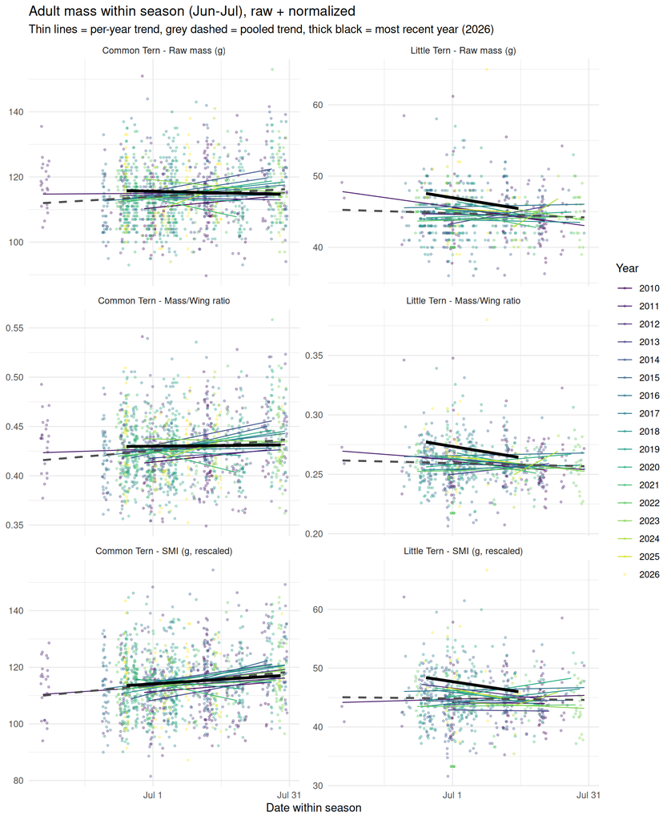

```r
make_season_plot_allmetrics(w_junjul_norm, "Jun-Jul", c(0, 30, 61), c("Jun 1", "Jul 1", "Jul 31"))
```

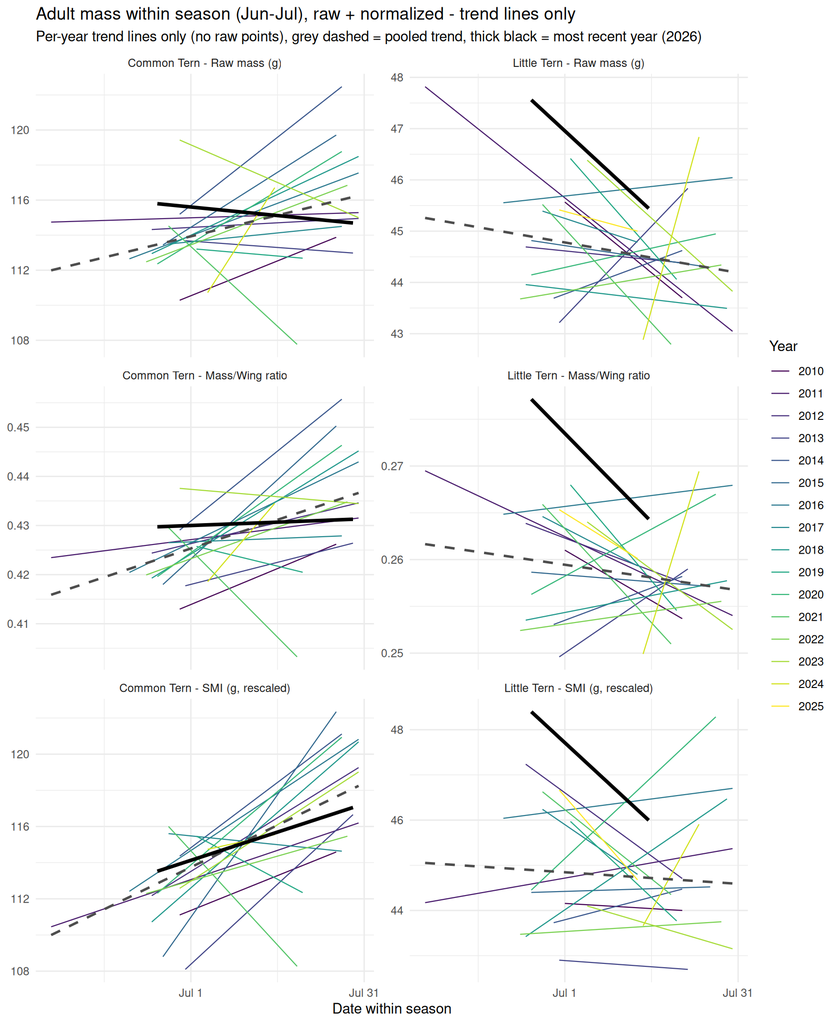

```r
make_season_plot_allmetrics(w_junjul_norm, "Jun-Jul", c(0, 30, 61), c("Jun 1", "Jul 1", "Jul 31"), show_points = FALSE)
```

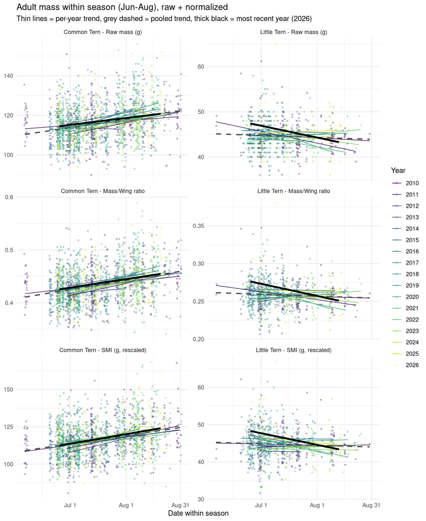

```r
make_season_plot_allmetrics(w_junaug_norm, "Jun-Aug", c(0, 30, 61, 91), c("Jun 1", "Jul 1", "Aug 1", "Aug 31"))
```

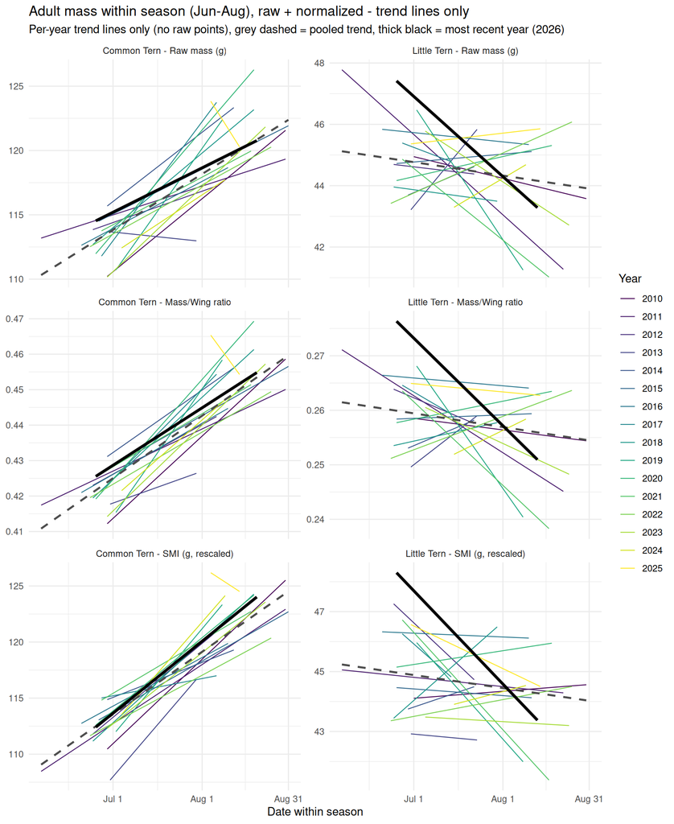

```r
make_season_plot_allmetrics(w_junaug_norm, "Jun-Aug", c(0, 30, 61, 91), c("Jun 1", "Jul 1", "Aug 1", "Aug 31"), show_points = FALSE)
```

# 7 Per-year slopes and recent-vs-historical test (Jun-Jul only)

August can include passage migrants as well as the local breeding population, so this follow-up restricts to the Jun-Jul window only.

## 7.1 Per-year within-season slope

Same Jun-Jul population as above, but fit separately per year instead of pooled, so each year’s own within-season trend is visible on its own. Years with fewer than 5 weighed records are dropped (too few points to fit a meaningful line) - in practice this only drops 2025 for Common Tern, which has zero Jun-Jul records that year.

```r
fit_peryear_metric <- function(df, metric) {
  form <- as.formula(paste0(metric, " ~ day_of_season"))
  df %>%
    group_by(species_label, year) %>%
    filter(n() >= 5) %>%
    group_modify(~ {
      m <- lm(form, data = .x)
      s <- summary(m)
      tibble(
        n = nrow(.x),
        slope = round(coef(m)["day_of_season"], 4),
        se = round(s$coefficients["day_of_season", "Std. Error"], 4),
        p_value = signif(s$coefficients["day_of_season", "Pr(>|t|)"], 3)
      )
    }) %>%
    ungroup() %>%
    mutate(metric = metric)
}

peryear_junjul <- bind_rows(
  fit_peryear_metric(w_junjul_norm, "Weight"),
  fit_peryear_metric(w_junjul_norm, "mass_ratio"),
  fit_peryear_metric(w_junjul_norm, "smi")
) %>%
  mutate(metric = relabel_metric(metric)) %>%
  arrange(species_label, metric, year)

kable(peryear_junjul, digits = 4,
      caption = "Per-year value ~ day_of_season slope, Jun-Jul, all three metrics (years with n >= 5 only; slope units depend on metric - g/day for raw mass and SMI, ratio-units/day for mass/wing ratio)")
```

Per-year value ~ day_of_season slope, Jun-Jul, all three metrics (years with n >= 5 only; slope units depend on metric - g/day for raw mass and SMI, ratio-units/day for mass/wing ratio)

| species_label | year | n | slope | se | p_value | metric |
| --- | --- | --- | --- | --- | --- | --- |
| Common Tern | 2010 | 62 | 0.1282 | 0.1444 | 0.3780 | Raw mass (g) |
| Common Tern | 2011 | 121 | 0.0098 | 0.0496 | 0.8430 | Raw mass (g) |
| Common Tern | 2012 | 79 | 0.0170 | 0.0770 | 0.8260 | Raw mass (g) |
| Common Tern | 2013 | 38 | -0.0234 | 0.1777 | 0.8960 | Raw mass (g) |
| Common Tern | 2014 | 53 | 0.2509 | 0.1321 | 0.0632 | Raw mass (g) |
| Common Tern | 2015 | 51 | 0.2023 | 0.1255 | 0.1140 | Raw mass (g) |
| Common Tern | 2016 | 117 | 0.1195 | 0.0513 | 0.0217 | Raw mass (g) |
| Common Tern | 2017 | 119 | 0.0324 | 0.1065 | 0.7610 | Raw mass (g) |
| Common Tern | 2018 | 45 | 0.1498 | 0.1048 | 0.1600 | Raw mass (g) |
| Common Tern | 2019 | 76 | -0.0273 | 0.1441 | 0.8500 | Raw mass (g) |
| Common Tern | 2020 | 204 | 0.1944 | 0.0578 | 0.0009 | Raw mass (g) |
| Common Tern | 2021 | 58 | -0.2937 | 0.1400 | 0.0404 | Raw mass (g) |
| Common Tern | 2022 | 86 | 0.1213 | 0.0734 | 0.1020 | Raw mass (g) |
| Common Tern | 2023 | 48 | -0.1384 | 0.1559 | 0.3790 | Raw mass (g) |
| Common Tern | 2024 | 44 | 0.4991 | 0.2417 | 0.0451 | Raw mass (g) |
| Common Tern | 2026 | 82 | -0.0314 | 0.1130 | 0.7810 | Raw mass (g) |
| Common Tern | 2010 | 62 | 0.0005 | 0.0005 | 0.3510 | Mass/Wing ratio |
| Common Tern | 2011 | 121 | 0.0001 | 0.0002 | 0.4290 | Mass/Wing ratio |
| Common Tern | 2012 | 79 | 0.0003 | 0.0003 | 0.3390 | Mass/Wing ratio |
| Common Tern | 2013 | 38 | 0.0003 | 0.0006 | 0.6420 | Mass/Wing ratio |
| Common Tern | 2014 | 53 | 0.0009 | 0.0005 | 0.0839 | Mass/Wing ratio |
| Common Tern | 2015 | 51 | 0.0010 | 0.0004 | 0.0148 | Mass/Wing ratio |
| Common Tern | 2016 | 117 | 0.0005 | 0.0002 | 0.0021 | Mass/Wing ratio |
| Common Tern | 2017 | 119 | 0.0000 | 0.0004 | 0.9080 | Mass/Wing ratio |
| Common Tern | 2018 | 45 | 0.0007 | 0.0004 | 0.0760 | Mass/Wing ratio |
| Common Tern | 2019 | 76 | -0.0003 | 0.0005 | 0.5950 | Mass/Wing ratio |
| Common Tern | 2020 | 204 | 0.0008 | 0.0002 | 0.0001 | Mass/Wing ratio |
| Common Tern | 2021 | 58 | -0.0011 | 0.0005 | 0.0169 | Mass/Wing ratio |
| Common Tern | 2022 | 86 | 0.0004 | 0.0003 | 0.1250 | Mass/Wing ratio |
| Common Tern | 2023 | 48 | -0.0001 | 0.0005 | 0.8590 | Mass/Wing ratio |

[output cut: 69 more lines]

```r
kable(peryear_junjul %>%
        group_by(species_label, metric) %>%
        summarise(n_years = n(), n_negative = sum(slope < 0),
                  n_positive = sum(slope > 0), .groups = "drop"),
      caption = "Sign of the per-year slope, Jun-Jul, all three metrics")
```

Sign of the per-year slope, Jun-Jul, all three metrics

| species_label | metric | n_years | n_negative | n_positive |
| --- | --- | --- | --- | --- |
| Common Tern | Raw mass (g) | 16 | 5 | 11 |
| Common Tern | Mass/Wing ratio | 16 | 3 | 11 |
| Common Tern | SMI (g, rescaled) | 16 | 3 | 13 |
| Little Tern | Raw mass (g) | 17 | 11 | 6 |
| Little Tern | Mass/Wing ratio | 17 | 9 | 7 |
| Little Tern | SMI (g, rescaled) | 17 | 9 | 8 |

## 7.2 Is the most recent year (or last few years) different from the rest?

**Method and why:** to test whether one group of years has a different within-season slope than the rest, the raw records are pooled and fit with `Weight ~ day_of_season * group`, where `group` is a 2-level factor (recent vs. everyone else). The `day_of_season:group` interaction coefficient is literally the difference in slope between the two groups, with its own standard error and p-value. This is preferred over treating the per-year slopes above as a small sample and asking whether the most recent one is an outlier in that sample (e.g. a z-score against the spread of slopes) - that approach would treat each year’s slope as known exactly, when in fact most individual years are too noisy to trust on their own (see the p-value column above). Fitting on the pooled raw data instead lets years with more/cleaner data count for more, and is the same logic as the `day_of_season x year` interaction test used earlier in this script, just with `year` collapsed into two groups instead of kept as 17 separate levels.

Two group definitions are tested: the single most recent year (2026) vs. all other years, and the last 3 years *with data* vs. earlier years (“with data” rather than last 3 calendar years, since Common Tern has zero Jun-Jul records in 2025 - a calendar-year window would silently collapse that comparison to just 2 recent years for that species).

```r
test_recent_vs_rest <- function(df, group_years, group_label, metric) {
  d <- df %>%
    mutate(group = factor(ifelse(year %in% group_years, "recent", "other"),
                           levels = c("other", "recent")))
  form <- as.formula(paste0(metric, " ~ day_of_season * group"))
  m <- lm(form, data = d)
  s <- summary(m)
  slope_other <- coef(m)["day_of_season"]
  slope_diff <- coef(m)["day_of_season:grouprecent"]
  tibble(
    comparison = group_label,
    metric = metric,
    n_recent = sum(d$group == "recent"),
    n_other = sum(d$group == "other"),
    slope_other = round(slope_other, 4),
    slope_recent = round(slope_other + slope_diff, 4),
    slope_diff = round(slope_diff, 4),
    p_value = signif(s$coefficients["day_of_season:grouprecent", "Pr(>|t|)"], 3)
  )
}

metrics3 <- c("Weight", "mass_ratio", "smi")
recent_tests <- bind_rows(lapply(metrics3, function(met) {
  bind_rows(
    w_junjul_norm %>% filter(species_label == "Common Tern") %>%
      test_recent_vs_rest(2026, "Common Tern: 2026 vs. all other years", met),
    w_junjul_norm %>% filter(species_label == "Common Tern") %>%
      test_recent_vs_rest(c(2023, 2024, 2026), "Common Tern: last 3 yrs w/ data (2023, 2024, 2026) vs. earlier", met),
    w_junjul_norm %>% filter(species_label == "Little Tern") %>%
      test_recent_vs_rest(2026, "Little Tern: 2026 vs. all other years", met),
    w_junjul_norm %>% filter(species_label == "Little Tern") %>%
      test_recent_vs_rest(c(2024, 2025, 2026), "Little Tern: last 3 yrs w/ data (2024, 2025, 2026) vs. earlier", met)
  )
})) %>%
  mutate(metric = relabel_metric(metric)) %>%
  arrange(comparison, metric)

kable(recent_tests, digits = 4,
      caption = "Recent-years vs. historical within-season slope, Jun-Jul, all three metrics (day_of_season x group interaction test)")
```

Recent-years vs. historical within-season slope, Jun-Jul, all three metrics (day_of_season x group interaction test)

| comparison | metric | n_recent | n_other | slope_other | slope_recent | slope_diff | p_value |
| --- | --- | --- | --- | --- | --- | --- | --- |
| Common Tern: 2026 vs. all other years | Raw mass (g) | 82 | 1201 | 0.0832 | -0.0315 | -0.1147 | 0.2900 |
| Common Tern: 2026 vs. all other years | Mass/Wing ratio | 82 | 1201 | 0.0004 | 0.0000 | -0.0004 | 0.3680 |
| Common Tern: 2026 vs. all other years | SMI (g, rescaled) | 82 | 1201 | 0.1521 | 0.1007 | -0.0514 | 0.6930 |
| Common Tern: last 3 yrs w/ data (2023, 2024, 2026) vs. earlier | Raw mass (g) | 174 | 1109 | 0.0891 | 0.0034 | -0.0857 | 0.1400 |
| Common Tern: last 3 yrs w/ data (2023, 2024, 2026) vs. earlier | Mass/Wing ratio | 174 | 1109 | 0.0004 | 0.0002 | -0.0002 | 0.3130 |
| Common Tern: last 3 yrs w/ data (2023, 2024, 2026) vs. earlier | SMI (g, rescaled) | 174 | 1109 | 0.1481 | 0.1512 | 0.0031 | 0.9650 |
| Little Tern: 2026 vs. all other years | Raw mass (g) | 23 | 660 | -0.0169 | -0.1008 | -0.0839 | 0.4430 |
| Little Tern: 2026 vs. all other years | Mass/Wing ratio | 23 | 660 | -0.0001 | -0.0006 | -0.0005 | 0.3940 |
| Little Tern: 2026 vs. all other years | SMI (g, rescaled) | 23 | 660 | -0.0054 | -0.1144 | -0.1090 | 0.4290 |
| Little Tern: last 3 yrs w/ data (2024, 2025, 2026) vs. earlier | Raw mass (g) | 42 | 641 | -0.0161 | -0.1073 | -0.0912 | 0.1780 |
| Little Tern: last 3 yrs w/ data (2024, 2025, 2026) vs. earlier | Mass/Wing ratio | 42 | 641 | -0.0001 | -0.0007 | -0.0006 | 0.1090 |
| Little Tern: last 3 yrs w/ data (2024, 2025, 2026) vs. earlier | SMI (g, rescaled) | 42 | 641 | -0.0037 | -0.1445 | -0.1408 | 0.0985 |

**No significant difference for either species, under any of the three metrics, under either definition of “recent”** (all twelve interaction p-values > 0.09). Despite 2026 (and the last few years) visually looking flat/down for Common Tern against a pooled upward historical trend, that gap is not statistically distinguishable from the year-to-year noise already present in the historical data - individual “ordinary” years swing from -0.29 to +0.50 g/day on raw mass (see per-year table above), and normalizing to wing length doesn’t change that picture. This is a genuine null result rather than an underpowered one in an absolute sense - the “other years” side of each comparison has hundreds of records - but with only n=82 (Common Tern) / n=23 (Little Tern) on the “recent” side, a modest true shift could still be missed; read this as “no evidence of a recent shift,” not “definitively no shift.”

# 8 Interpretation

A significant pooled slope (first table in each window section) means mass systematically changes over the course of that window, averaged across all years. A significant `day_of_season x year` interaction means that pattern isn’t consistent from year to year - some years may show a strong trend and others none, or even the opposite direction - so the pooled slope should be read as an average tendency, not something that holds every single year. A non-significant interaction means the pooled slope is a reasonably good summary of what happens within any given year’s season on its own. Read both together with the per-year plot, which makes any single outlier year visually obvious (color-graded by year - a year that stands out from the rest is visible regardless of whether it’s an early or recent year).

# 9 Save outputs

```r
all_pooled <- bind_rows(res_junjul$pooled, res_junaug$pooled)
all_interaction <- bind_rows(res_junjul$interaction, res_junaug$interaction)

write.csv(all_pooled, file.path(proc_dir, "summer_adult_within_season_pooled_stats.csv"), row.names = FALSE)
write.csv(all_interaction, file.path(proc_dir, "summer_adult_within_season_interaction_stats.csv"), row.names = FALSE)
write.csv(peryear_junjul, file.path(proc_dir, "summer_adult_within_season_junjul_peryear_slopes.csv"), row.names = FALSE)
write.csv(recent_tests, file.path(proc_dir, "summer_adult_within_season_junjul_recent_vs_historical.csv"), row.names = FALSE)

all_pooled_norm <- bind_rows(norm_junjul$pooled, norm_junaug$pooled)
all_interaction_norm <- bind_rows(norm_junjul$interaction, norm_junaug$interaction)
write.csv(all_pooled_norm, file.path(proc_dir, "summer_adult_within_season_pooled_stats_normalized.csv"), row.names = FALSE)
write.csv(all_interaction_norm, file.path(proc_dir, "summer_adult_within_season_interaction_stats_normalized.csv"), row.names = FALSE)
write.csv(bind_rows(w_junjul_norm %>% mutate(window = "Jun-Jul"), w_junaug_norm %>% mutate(window = "Jun-Aug")) %>%
            select(species_label, window, year, date, day_of_season, Weight, Wing, mass_ratio, smi),
          file.path(proc_dir, "summer_adult_within_season_normalized_records.csv"), row.names = FALSE)

cat("Wrote data_processed/summer_adult_within_season_pooled_stats.csv, summer_adult_within_season_interaction_stats.csv,",
    "summer_adult_within_season_junjul_peryear_slopes.csv, summer_adult_within_season_junjul_recent_vs_historical.csv,",
    "summer_adult_within_season_pooled_stats_normalized.csv, summer_adult_within_season_interaction_stats_normalized.csv",
    "and summer_adult_within_season_normalized_records.csv\n")
```

[output not shown]